# Tidymodel Applications in 1,5 AG Analysis

Arin Vansomphone

2022-08-18

I attempt to fit the best model that can predict whether a person has abnormal 1,5 AG levels.

Loading the packages:

```r
library(tidyverse)
library(readxl)
library(tidymodels)
library(readr)
library(vip)
```

Loading the data:

```r
bloodpressure <- read_csv("bloodpressure.csv")
hba1c <- read_csv("hba1c.csv")
AG <- read_xlsx("UCLA Samples-2022-07-19 Summary.xlsx", sheet = "Summary",
                skip = 7) %>%
  rename(BSI_ID = `Sample ID`)
linkfile <- read_csv("zhou_7816_linkfile.csv")
accord_key <- read_csv("accord_key.csv")
microvascularoutcomes <- read_csv("microvascularoutcomes.csv")
cvdoutcomes <- read_csv("cvdoutcomes.csv")
```

```r
f07_baseline <- read_csv("f07_baselinehistoryphysicalexam.csv")
otherlabs <- read_csv("otherlabs.csv")
bloodpressure <- read_csv("bloodpressure.csv")
lipids <- read_csv("lipids.csv")
concomitantmeds <- read_csv("concomitantmeds.csv")
AG
```

```
## # A tibble: 4,000 × 6
##    `R2020 000036` `Sample #` BSI_ID        `Rep 1` `Rep 2`  Mean
##    <chr>               <dbl> <chr>           <dbl>   <dbl> <dbl>
##  1 Box 1                   1 KB 010495 001    12      12.1  12.0
##  2 Box 1                   2 KB 036551 001    19.9    19.7  19.8
##  3 Box 1                   3 KB 011404 001    13.8    13.4  13.6
##  4 Box 1                   4 KB 034788 001    17.5    17.7  17.6
##  5 Box 1                   5 KB 010382 001    17.3    17.5  17.4
##  6 Box 1                   6 KB 013283 001    27      26.7  26.8
##  7 Box 1                   7 KB 011444 001     9.3     9.7   9.5
##  8 Box 1                   8 KB 040903 001    23.3    23.2  23.2
##  9 Box 1                   9 KB 021249 001    13.4    13.3  13.4
## 10 Box 1                  10 KB 029172 001    43.5    44.1  43.8
## # … with 3,990 more rows
```

Tidying the data and creating other variables:

```r
AG <- AG %>% #linking MASKID to Batch ID
  full_join(linkfile, by = "BSI_ID") %>%
  filter(!is.na(MASKID) ) %>%
  rename(MaskID = MASKID,
         Box = `R2020 000036`)
AG
```

```
## # A tibble: 4,000 × 7
##    Box   `Sample #` BSI_ID        `Rep 1` `Rep 2`  Mean MaskID
##    <chr>      <dbl> <chr>           <dbl>   <dbl> <dbl>  <dbl>
##  1 Box 1          1 KB 010495 001    12      12.1  12.0 101121
##  2 Box 1          2 KB 036551 001    19.9    19.7  19.8 107910
##  3 Box 1          3 KB 011404 001    13.8    13.4  13.6 101341
##  4 Box 1          4 KB 034788 001    17.5    17.7  17.6 107434
##  5 Box 1          5 KB 010382 001    17.3    17.5  17.4 101093
##  6 Box 1          6 KB 013283 001    27      26.7  26.8 101814
##  7 Box 1          7 KB 011444 001     9.3     9.7   9.5 101354
##  8 Box 1          8 KB 040903 001    23.3    23.2  23.2 109136
##  9 Box 1          9 KB 021249 001    13.4    13.3  13.4 103931
## 10 Box 1         10 KB 029172 001    43.5    44.1  43.8 105989
## # … with 3,990 more rows
```

```r
# creating a BatchID column
BatchIDs <- c("R2020 000036", "R2020 000037", "R2020 000038", "R2020 000039",
             "R2020 000040", "R2020 000041", "R2020 000042", "R2020 000043")
index = c(1, which(AG$Box %in% BatchIDs), 4001)
BatchID_col = rep(BatchIDs, diff(index))
AG <- AG %>% mutate(BatchID = BatchID_col) %>%
  relocate(BatchID, .before = Box) %>%
  relocate(MaskID, .after = BSI_ID)
AG
```

```
## # A tibble: 4,000 × 8
##    BatchID      Box   `Sample #` BSI_ID        MaskID `Rep 1` `Rep 2`  Mean
##    <chr>        <chr>      <dbl> <chr>          <dbl>   <dbl>   <dbl> <dbl>
##  1 R2020 000036 Box 1          1 KB 010495 001 101121    12      12.1  12.0
##  2 R2020 000036 Box 1          2 KB 036551 001 107910    19.9    19.7  19.8
##  3 R2020 000036 Box 1          3 KB 011404 001 101341    13.8    13.4  13.6
##  4 R2020 000036 Box 1          4 KB 034788 001 107434    17.5    17.7  17.6
##  5 R2020 000036 Box 1          5 KB 010382 001 101093    17.3    17.5  17.4
##  6 R2020 000036 Box 1          6 KB 013283 001 101814    27      26.7  26.8
##  7 R2020 000036 Box 1          7 KB 011444 001 101354     9.3     9.7   9.5
##  8 R2020 000036 Box 1          8 KB 040903 001 109136    23.3    23.2  23.2
##  9 R2020 000036 Box 1          9 KB 021249 001 103931    13.4    13.3  13.4
## 10 R2020 000036 Box 1         10 KB 029172 001 105989    43.5    44.1  43.8
## # … with 3,990 more rows
```

```r
# replacing errors in Box
AG["Box"][AG["Box"] == "R2020 000037"] <- "Box 1"
AG["Box"][AG["Box"] == "R2020 000038"] <- "Box 1"
AG["Box"][AG["Box"] == "R2020 000039"] <- "Box 1"
AG["Box"][AG["Box"] == "R2020 000040"] <- "Box 1"
AG["Box"][AG["Box"] == "R2020 000041"] <- "Box 1"
AG["Box"][AG["Box"] == "R2020 000042"] <- "Box 1"
AG["Box"][AG["Box"] == "R2020 000043"] <- "Box 1"
AG
```

```
## # A tibble: 4,000 × 8
##    BatchID      Box   `Sample #` BSI_ID        MaskID `Rep 1` `Rep 2`  Mean
##    <chr>        <chr>      <dbl> <chr>          <dbl>   <dbl>   <dbl> <dbl>
##  1 R2020 000036 Box 1          1 KB 010495 001 101121    12      12.1  12.0
##  2 R2020 000036 Box 1          2 KB 036551 001 107910    19.9    19.7  19.8
##  3 R2020 000036 Box 1          3 KB 011404 001 101341    13.8    13.4  13.6
##  4 R2020 000036 Box 1          4 KB 034788 001 107434    17.5    17.7  17.6
##  5 R2020 000036 Box 1          5 KB 010382 001 101093    17.3    17.5  17.4
##  6 R2020 000036 Box 1          6 KB 013283 001 101814    27      26.7  26.8
##  7 R2020 000036 Box 1          7 KB 011444 001 101354     9.3     9.7   9.5
##  8 R2020 000036 Box 1          8 KB 040903 001 109136    23.3    23.2  23.2
##  9 R2020 000036 Box 1          9 KB 021249 001 103931    13.4    13.3  13.4
## 10 R2020 000036 Box 1         10 KB 029172 001 105989    43.5    44.1  43.8
## # … with 3,990 more rows
```

```r
# joining hba1c with the AG dataframe
AG <- AG %>%
  inner_join(hba1c, by = "MaskID")
AG
```

```
## # A tibble: 59,036 × 10
##    BatchID      Box   `Sample #` BSI_ID MaskID `Rep 1` `Rep 2`  Mean Visit hba1c
##    <chr>        <chr>      <dbl> <chr>   <dbl>   <dbl>   <dbl> <dbl> <chr> <dbl>
##  1 R2020 000036 Box 1          1 KB 01… 101121      12    12.1  12.0 BLR     7
##  2 R2020 000036 Box 1          1 KB 01… 101121      12    12.1  12.0 F04     6.6
##  3 R2020 000036 Box 1          1 KB 01… 101121      12    12.1  12.0 F08     6
##  4 R2020 000036 Box 1          1 KB 01… 101121      12    12.1  12.0 F12     5.4
##  5 R2020 000036 Box 1          1 KB 01… 101121      12    12.1  12.0 F16     5.8
##  6 R2020 000036 Box 1          1 KB 01… 101121      12    12.1  12.0 F20     6.1
##  7 R2020 000036 Box 1          1 KB 01… 101121      12    12.1  12.0 F24     6
##  8 R2020 000036 Box 1          1 KB 01… 101121      12    12.1  12.0 F28     5.7
##  9 R2020 000036 Box 1          1 KB 01… 101121      12    12.1  12.0 F32     6.2
## 10 R2020 000036 Box 1          1 KB 01… 101121      12    12.1  12.0 F36     6.3
## # … with 59,026 more rows
```

```r
# joining other dataframes
AG <- AG %>%
 left_join(accord_key, by= "MaskID") %>%
 left_join(f07_baseline, by = c("MaskID", "Visit")) %>%
 left_join(lipids, by = c("MaskID", "Visit")) %>%
 left_join(bloodpressure, by = c("MaskID", "Visit")) %>%
 left_join(otherlabs, by = c("MaskID", "Visit")) %>%
 left_join(concomitantmeds, by = c("MaskID", "Visit"))
AG
```

```
## # A tibble: 59,036 × 148
##    BatchID      Box   `Sample #` BSI_ID MaskID `Rep 1` `Rep 2`  Mean Visit hba1c
##    <chr>        <chr>      <dbl> <chr>   <dbl>   <dbl>   <dbl> <dbl> <chr> <dbl>
##  1 R2020 000036 Box 1          1 KB 01… 101121      12    12.1  12.0 BLR     7
##  2 R2020 000036 Box 1          1 KB 01… 101121      12    12.1  12.0 F04     6.6
##  3 R2020 000036 Box 1          1 KB 01… 101121      12    12.1  12.0 F08     6
##  4 R2020 000036 Box 1          1 KB 01… 101121      12    12.1  12.0 F12     5.4
##  5 R2020 000036 Box 1          1 KB 01… 101121      12    12.1  12.0 F16     5.8
##  6 R2020 000036 Box 1          1 KB 01… 101121      12    12.1  12.0 F20     6.1
##  7 R2020 000036 Box 1          1 KB 01… 101121      12    12.1  12.0 F24     6
##  8 R2020 000036 Box 1          1 KB 01… 101121      12    12.1  12.0 F28     5.7
##  9 R2020 000036 Box 1          1 KB 01… 101121      12    12.1  12.0 F32     6.2
## 10 R2020 000036 Box 1          1 KB 01… 101121      12    12.1  12.0 F36     6.3
## # … with 59,026 more rows, and 138 more variables: female <dbl>,
## #   baseline_age <dbl>, arm <dbl>, treatment <chr>, trial_elig <dbl>,
## #   cvd_hx_baseline <dbl>, network <dbl>, raceclass <chr>, livealon <dbl>,
## #   edu <dbl>, yrsdiab <dbl>, yrslipi <dbl>, yrstens <dbl>, ulcer <dbl>,
## #   protein <dbl>, hartfail <dbl>, neuropat <dbl>, depressn <dbl>,
## #   eyedisea <dbl>, histhart <dbl>, cigarett <dbl>, smokelif <dbl>,
## #   quityrs <dbl>, alcohol <dbl>, ins_cover <dbl>, dk_unins <dbl>, …
```

```r
# creating glycemic, bp, and lipid arm variables
AG <- AG %>%
mutate(glycemic_arm = ifelse(arm==1|arm==2|arm==5|arm==6,0,1),
         bp_arm = ifelse(arm==3 | arm ==1, 1, 0),
         lipid_arm = ifelse(arm==7 | arm == 5, 1, 0))
AG
```

```
## # A tibble: 59,036 × 151
##    BatchID      Box   `Sample #` BSI_ID MaskID `Rep 1` `Rep 2`  Mean Visit hba1c
##    <chr>        <chr>      <dbl> <chr>   <dbl>   <dbl>   <dbl> <dbl> <chr> <dbl>
##  1 R2020 000036 Box 1          1 KB 01… 101121      12    12.1  12.0 BLR     7
##  2 R2020 000036 Box 1          1 KB 01… 101121      12    12.1  12.0 F04     6.6
##  3 R2020 000036 Box 1          1 KB 01… 101121      12    12.1  12.0 F08     6
##  4 R2020 000036 Box 1          1 KB 01… 101121      12    12.1  12.0 F12     5.4
##  5 R2020 000036 Box 1          1 KB 01… 101121      12    12.1  12.0 F16     5.8
##  6 R2020 000036 Box 1          1 KB 01… 101121      12    12.1  12.0 F20     6.1
##  7 R2020 000036 Box 1          1 KB 01… 101121      12    12.1  12.0 F24     6
##  8 R2020 000036 Box 1          1 KB 01… 101121      12    12.1  12.0 F28     5.7
##  9 R2020 000036 Box 1          1 KB 01… 101121      12    12.1  12.0 F32     6.2
## 10 R2020 000036 Box 1          1 KB 01… 101121      12    12.1  12.0 F36     6.3
## # … with 59,026 more rows, and 141 more variables: female <dbl>,
## #   baseline_age <dbl>, arm <dbl>, treatment <chr>, trial_elig <dbl>,
## #   cvd_hx_baseline <dbl>, network <dbl>, raceclass <chr>, livealon <dbl>,
## #   edu <dbl>, yrsdiab <dbl>, yrslipi <dbl>, yrstens <dbl>, ulcer <dbl>,
## #   protein <dbl>, hartfail <dbl>, neuropat <dbl>, depressn <dbl>,
## #   eyedisea <dbl>, histhart <dbl>, cigarett <dbl>, smokelif <dbl>,
## #   quityrs <dbl>, alcohol <dbl>, ins_cover <dbl>, dk_unins <dbl>, …
```

```r
# creating the kidney variable
baseline_ualb <- otherlabs %>%
  filter(Visit == "BLR") %>%
  mutate(kidney = ifelse(gfr < 45 | ualb > 300, 1, 0)) %>%
  select(MaskID, -Visit, kidney)
baseline_ualb
```

```
## # A tibble: 10,240 × 2
##    MaskID kidney
##     <dbl>  <dbl>
##  1 100001      0
##  2 100002      0
##  3 100003      0
##  4 100004      0
##  5 100005      0
##  6 100006      0
##  7 100007      0
##  8 100008      0
##  9 100009      0
## 10 100010      0
## # … with 10,230 more rows
```

```r
# joining the kidney variable with the main dataframe
AG <- AG %>%
  inner_join(baseline_ualb, by = "MaskID")
AG
```

```
## # A tibble: 58,997 × 152
##    BatchID      Box   `Sample #` BSI_ID MaskID `Rep 1` `Rep 2`  Mean Visit hba1c
##    <chr>        <chr>      <dbl> <chr>   <dbl>   <dbl>   <dbl> <dbl> <chr> <dbl>
##  1 R2020 000036 Box 1          1 KB 01… 101121      12    12.1  12.0 BLR     7
##  2 R2020 000036 Box 1          1 KB 01… 101121      12    12.1  12.0 F04     6.6
##  3 R2020 000036 Box 1          1 KB 01… 101121      12    12.1  12.0 F08     6
##  4 R2020 000036 Box 1          1 KB 01… 101121      12    12.1  12.0 F12     5.4
##  5 R2020 000036 Box 1          1 KB 01… 101121      12    12.1  12.0 F16     5.8
##  6 R2020 000036 Box 1          1 KB 01… 101121      12    12.1  12.0 F20     6.1
##  7 R2020 000036 Box 1          1 KB 01… 101121      12    12.1  12.0 F24     6
##  8 R2020 000036 Box 1          1 KB 01… 101121      12    12.1  12.0 F28     5.7
##  9 R2020 000036 Box 1          1 KB 01… 101121      12    12.1  12.0 F32     6.2
## 10 R2020 000036 Box 1          1 KB 01… 101121      12    12.1  12.0 F36     6.3
## # … with 58,987 more rows, and 142 more variables: female <dbl>,
## #   baseline_age <dbl>, arm <dbl>, treatment <chr>, trial_elig <dbl>,
## #   cvd_hx_baseline <dbl>, network <dbl>, raceclass <chr>, livealon <dbl>,
## #   edu <dbl>, yrsdiab <dbl>, yrslipi <dbl>, yrstens <dbl>, ulcer <dbl>,
## #   protein <dbl>, hartfail <dbl>, neuropat <dbl>, depressn <dbl>,
## #   eyedisea <dbl>, histhart <dbl>, cigarett <dbl>, smokelif <dbl>,
## #   quityrs <dbl>, alcohol <dbl>, ins_cover <dbl>, dk_unins <dbl>, …
```

```r
# mutating other biomarkers
AG <- AG %>%
  mutate(bmi = wt_kg / ((ht_cm / 100) ^ 2)) %>%
  mutate(insulin = ifelse(nphl_insulin==1|reg_insulin==1|la_insulin==1 |
                         othbol_insulin==1 |premix_insulin == 1, 1, 0))
AG
```

```
## # A tibble: 58,997 × 154
##    BatchID      Box   `Sample #` BSI_ID MaskID `Rep 1` `Rep 2`  Mean Visit hba1c
##    <chr>        <chr>      <dbl> <chr>   <dbl>   <dbl>   <dbl> <dbl> <chr> <dbl>
##  1 R2020 000036 Box 1          1 KB 01… 101121      12    12.1  12.0 BLR     7
##  2 R2020 000036 Box 1          1 KB 01… 101121      12    12.1  12.0 F04     6.6
##  3 R2020 000036 Box 1          1 KB 01… 101121      12    12.1  12.0 F08     6
##  4 R2020 000036 Box 1          1 KB 01… 101121      12    12.1  12.0 F12     5.4
##  5 R2020 000036 Box 1          1 KB 01… 101121      12    12.1  12.0 F16     5.8
##  6 R2020 000036 Box 1          1 KB 01… 101121      12    12.1  12.0 F20     6.1
##  7 R2020 000036 Box 1          1 KB 01… 101121      12    12.1  12.0 F24     6
##  8 R2020 000036 Box 1          1 KB 01… 101121      12    12.1  12.0 F28     5.7
##  9 R2020 000036 Box 1          1 KB 01… 101121      12    12.1  12.0 F32     6.2
## 10 R2020 000036 Box 1          1 KB 01… 101121      12    12.1  12.0 F36     6.3
## # … with 58,987 more rows, and 144 more variables: female <dbl>,
## #   baseline_age <dbl>, arm <dbl>, treatment <chr>, trial_elig <dbl>,
## #   cvd_hx_baseline <dbl>, network <dbl>, raceclass <chr>, livealon <dbl>,
## #   edu <dbl>, yrsdiab <dbl>, yrslipi <dbl>, yrstens <dbl>, ulcer <dbl>,
## #   protein <dbl>, hartfail <dbl>, neuropat <dbl>, depressn <dbl>,
## #   eyedisea <dbl>, histhart <dbl>, cigarett <dbl>, smokelif <dbl>,
## #   quityrs <dbl>, alcohol <dbl>, ins_cover <dbl>, dk_unins <dbl>, …
```

According to this [paper](https://www.ncbi.nlm.nih.gov/pmc/articles/PMC4411548/#:~:text=The%20normal%20ranges%20are%2010.7,%25%20to%206.0%25%20for%20HbA1c.), normal 1,5 AG levels range from 10.7 to 32.0.

```r
AG <- AG %>%
  mutate(Mean_group = ifelse(10.7 <= Mean & Mean <= 32.0,
                             "Normal", "Abnormal"))
AG
```

```
## # A tibble: 58,997 × 155
##    BatchID      Box   `Sample #` BSI_ID MaskID `Rep 1` `Rep 2`  Mean Visit hba1c
##    <chr>        <chr>      <dbl> <chr>   <dbl>   <dbl>   <dbl> <dbl> <chr> <dbl>
##  1 R2020 000036 Box 1          1 KB 01… 101121      12    12.1  12.0 BLR     7
##  2 R2020 000036 Box 1          1 KB 01… 101121      12    12.1  12.0 F04     6.6
##  3 R2020 000036 Box 1          1 KB 01… 101121      12    12.1  12.0 F08     6
##  4 R2020 000036 Box 1          1 KB 01… 101121      12    12.1  12.0 F12     5.4
##  5 R2020 000036 Box 1          1 KB 01… 101121      12    12.1  12.0 F16     5.8
##  6 R2020 000036 Box 1          1 KB 01… 101121      12    12.1  12.0 F20     6.1
##  7 R2020 000036 Box 1          1 KB 01… 101121      12    12.1  12.0 F24     6
##  8 R2020 000036 Box 1          1 KB 01… 101121      12    12.1  12.0 F28     5.7
##  9 R2020 000036 Box 1          1 KB 01… 101121      12    12.1  12.0 F32     6.2
## 10 R2020 000036 Box 1          1 KB 01… 101121      12    12.1  12.0 F36     6.3
## # … with 58,987 more rows, and 145 more variables: female <dbl>,
## #   baseline_age <dbl>, arm <dbl>, treatment <chr>, trial_elig <dbl>,
## #   cvd_hx_baseline <dbl>, network <dbl>, raceclass <chr>, livealon <dbl>,
## #   edu <dbl>, yrsdiab <dbl>, yrslipi <dbl>, yrstens <dbl>, ulcer <dbl>,
## #   protein <dbl>, hartfail <dbl>, neuropat <dbl>, depressn <dbl>,
## #   eyedisea <dbl>, histhart <dbl>, cigarett <dbl>, smokelif <dbl>,
## #   quityrs <dbl>, alcohol <dbl>, ins_cover <dbl>, dk_unins <dbl>, …
```

Now I select the top ten largest factors that contribute to 1,5 AG. These factors were taken from Tomoki’s univariate regression results (see his Week 8 solutions). The factors are: * Glycemic Arm * Lipid Arm * BP Arm * Ethnicity * Gender * hba1c * Insulin * Kidney * a2rb * Biguanide

I also filter the database so that only baseline measurements are taken.

```r
AG <- AG %>%
  filter(Visit == "BLR") %>%
  select(Mean_group, glycemic_arm, lipid_arm, bp_arm, raceclass, female,
         hba1c, insulin, kidney, a2rb, biguanide) %>%
  na.omit()
AG
```

```
## # A tibble: 3,923 × 11
##    Mean_group glycemic_arm lipid_arm bp_arm raceclass female hba1c insulin
##    <chr>             <dbl>     <dbl>  <dbl> <chr>      <dbl> <dbl>   <dbl>
##  1 Normal                1         1      0 Hispanic       1   7         0
##  2 Normal                1         1      0 Black          0   8.5       0
##  3 Normal                1         0      0 White          0   8.4       0
##  4 Normal                1         0      1 White          1   7.6       0
##  5 Normal                0         0      1 White          0   8.9       1
##  6 Normal                1         0      0 White          1   7         0
##  7 Abnormal              0         0      0 White          0   7.9       1
##  8 Normal                0         0      1 Black          1   7.5       1
##  9 Normal                0         0      0 White          0   8         1
## 10 Abnormal              1         0      1 White          0   7.5       1
## # … with 3,913 more rows, and 3 more variables: kidney <dbl>, a2rb <dbl>,
## #   biguanide <dbl>
```

Changing all of the categorical variables to factors:

```r
AG$glycemic_arm <- as.character(AG$glycemic_arm)
AG$glycemic_arm <- as.factor(AG$glycemic_arm)
AG$lipid_arm <- as.character(AG$lipid_arm)
AG$lipid_arm <- as.factor(AG$lipid_arm)
AG$bp_arm <- as.character(AG$bp_arm)
AG$bp_arm <- as.factor(AG$bp_arm)
AG$raceclass <- as.factor(AG$raceclass)
AG$female <- as.character(AG$female)
AG$female <- as.factor(AG$female)
AG$insulin <- as.character(AG$insulin)
AG$insulin <- as.factor(AG$insulin)
AG$kidney <- as.character(AG$kidney)
AG$kidney <- as.factor(AG$kidney)
AG$a2rb <- as.character(AG$a2rb)
AG$a2rb <- as.factor(AG$a2rb)
AG$biguanide <- as.character(AG$biguanide)
AG$biguanide <- as.factor(AG$biguanide)
AG$Mean_group <- as.factor(AG$Mean_group)
glimpse(AG)
```

```
## Rows: 3,923
## Columns: 11
## $ Mean_group   <fct> Normal, Normal, Normal, Normal, Normal, Normal, Abnormal,…
## $ glycemic_arm <fct> 1, 1, 1, 1, 0, 1, 0, 0, 0, 1, 0, 0, 1, 1, 1, 0, 1, 0, 1, …
## $ lipid_arm    <fct> 1, 1, 0, 0, 0, 0, 0, 0, 0, 0, 1, 0, 0, 0, 0, 1, 1, 0, 0, …
## $ bp_arm       <fct> 0, 0, 0, 1, 1, 0, 0, 1, 0, 1, 0, 1, 1, 0, 0, 0, 0, 0, 0, …
## $ raceclass    <fct> Hispanic, Black, White, White, White, White, White, Black…
## $ female       <fct> 1, 0, 0, 1, 0, 1, 0, 1, 0, 0, 1, 0, 1, 1, 0, 1, 1, 1, 1, …
## $ hba1c        <dbl> 7.0, 8.5, 8.4, 7.6, 8.9, 7.0, 7.9, 7.5, 8.0, 7.5, 8.6, 8.…
## $ insulin      <fct> 0, 0, 0, 0, 1, 0, 1, 1, 1, 1, 0, 1, 1, 0, 0, 0, 1, 0, 0, …
## $ kidney       <fct> 0, 0, 0, 0, 0, 0, 0, 0, 0, 0, 0, 0, 0, 0, 0, 0, 1, 0, 0, …
## $ a2rb         <fct> 0, 0, 0, 0, 0, 0, 0, 0, 0, 0, 1, 0, 0, 0, 0, 0, 0, 0, 0, …
## $ biguanide    <fct> 1, 1, 1, 1, 1, 1, 1, 1, 0, 1, 1, 1, 0, 1, 1, 1, 0, 1, 1, …
```

Finding out what percent of cases have abnormal 1,5 AG levels:

```r
AG %>%
  group_by(Mean_group) %>%
  summarize(Number = n(),
            Percent = Number / 3923)
```

```
## # A tibble: 2 × 3
##   Mean_group Number Percent
##   <fct>       <int>   <dbl>
## 1 Abnormal     2285   0.582
## 2 Normal       1638   0.418
```

Data splitting:

```r
set.seed(123)
splits <- initial_split(AG, strata = Mean_group)

AG_other <- training(splits)
AG_test <- testing(splits)

AG_other %>%
  count(Mean_group) %>%
  mutate(prop = n/sum(n))
```

```
## # A tibble: 2 × 3
##   Mean_group     n  prop
##   <fct>      <int> <dbl>
## 1 Abnormal    1713 0.582
## 2 Normal      1228 0.418
```

Creating a validation set:

```r
set.seed(234)
val_set <- validation_split(AG_other, strata = Mean_group, prop = 0.80)
val_set
```

```
## # Validation Set Split (0.8/0.2)  using stratification
## # A tibble: 1 × 2
##   splits             id
##   <list>             <chr>
## 1 <split [2352/589]> validation
```

Now we are ready to start modeling!

### Penalized Logistic Regression Model

Building the model:

```r
lr_mod <-
  logistic_reg(penalty = tune(), mixture = 1) %>%
  set_engine("glmnet")
```

Creating the recipe:

```r
lr_recipe <-
  recipe(Mean_group ~ ., data = AG_other) %>%
  step_dummy(all_nominal_predictors()) %>%
  step_zv(all_predictors()) %>%
  step_normalize(all_predictors())
```

Creating the workflow:

```r
lr_workflow <-
  workflow() %>%
  add_model(lr_mod) %>%
  add_recipe(lr_recipe)
```

Creating the grid for tuning:

```r
lr_reg_grid <- tibble(penalty = 10^seq(-4, -1, length.out = 30))
```

Training the model:

```r
lr_res <- lr_workflow %>%
  tune_grid(val_set, grid = lr_reg_grid,
            control = control_grid(save_pred = TRUE),
            metrics = metric_set(roc_auc))
```

Plotting the area under ROC curve for penalty values:

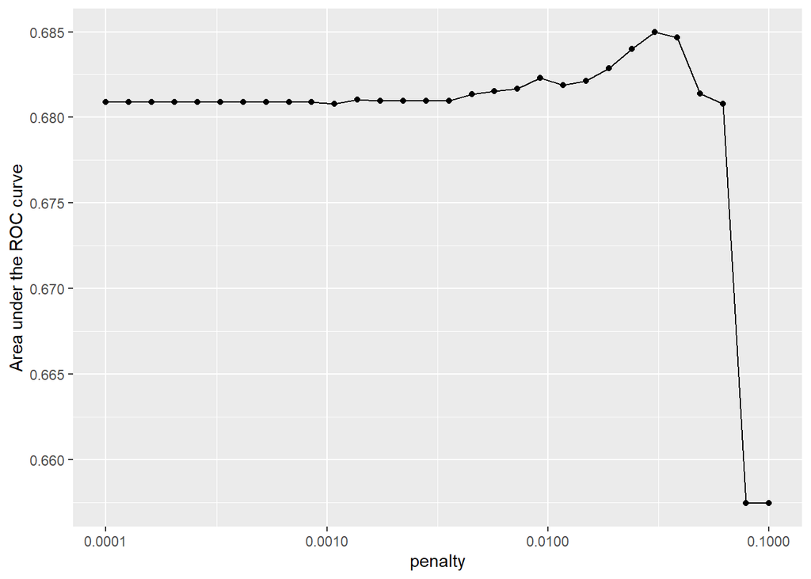

```r
lr_res %>%
  collect_metrics() %>%
  ggplot(aes(x = penalty, y = mean)) +
  geom_point() +
  geom_line() +
  ylab("Area under the ROC curve") +
  scale_x_log10(labels = scales::label_number())
```

```r
lr_res %>%
  show_best("roc_auc", n = 15) %>%
  arrange(penalty)
```

```
## # A tibble: 15 × 7
##    penalty .metric .estimator  mean     n std_err .config
##      <dbl> <chr>   <chr>      <dbl> <int>   <dbl> <chr>
##  1 0.00137 roc_auc binary     0.681     1      NA Preprocessor1_Model12
##  2 0.00221 roc_auc binary     0.681     1      NA Preprocessor1_Model14
##  3 0.00281 roc_auc binary     0.681     1      NA Preprocessor1_Model15
##  4 0.00356 roc_auc binary     0.681     1      NA Preprocessor1_Model16
##  5 0.00452 roc_auc binary     0.681     1      NA Preprocessor1_Model17
##  6 0.00574 roc_auc binary     0.682     1      NA Preprocessor1_Model18
##  7 0.00728 roc_auc binary     0.682     1      NA Preprocessor1_Model19
##  8 0.00924 roc_auc binary     0.682     1      NA Preprocessor1_Model20
##  9 0.0117  roc_auc binary     0.682     1      NA Preprocessor1_Model21
## 10 0.0149  roc_auc binary     0.682     1      NA Preprocessor1_Model22
## 11 0.0189  roc_auc binary     0.683     1      NA Preprocessor1_Model23
## 12 0.0240  roc_auc binary     0.684     1      NA Preprocessor1_Model24
## 13 0.0304  roc_auc binary     0.685     1      NA Preprocessor1_Model25
## 14 0.0386  roc_auc binary     0.685     1      NA Preprocessor1_Model26
## 15 0.0489  roc_auc binary     0.681     1      NA Preprocessor1_Model27
```

Selecting the best penalty value:

```r
lr_best <-
  lr_res %>%
  collect_metrics() %>%
  arrange(penalty) %>%
  slice(25)
lr_best
```

```
## # A tibble: 1 × 7
##   penalty .metric .estimator  mean     n std_err .config
##     <dbl> <chr>   <chr>      <dbl> <int>   <dbl> <chr>
## 1  0.0304 roc_auc binary     0.685     1      NA Preprocessor1_Model25
```

```r
lr_res %>%
  collect_predictions()
```

```
## # A tibble: 17,670 × 7
##    id         .pred_Abnormal .pred_Normal  .row penalty Mean_group .config
##    <chr>               <dbl>        <dbl> <int>   <dbl> <fct>      <chr>
##  1 validation          0.433        0.567     2  0.0001 Abnormal   Preprocessor…
##  2 validation          0.777        0.223     3  0.0001 Abnormal   Preprocessor…
##  3 validation          0.344        0.656     5  0.0001 Abnormal   Preprocessor…
##  4 validation          0.615        0.385    11  0.0001 Abnormal   Preprocessor…
##  5 validation          0.713        0.287    12  0.0001 Abnormal   Preprocessor…
##  6 validation          0.345        0.655    14  0.0001 Abnormal   Preprocessor…
##  7 validation          0.712        0.288    15  0.0001 Abnormal   Preprocessor…
##  8 validation          0.532        0.468    18  0.0001 Abnormal   Preprocessor…
##  9 validation          0.826        0.174    25  0.0001 Abnormal   Preprocessor…
## 10 validation          0.869        0.131    39  0.0001 Abnormal   Preprocessor…
## # … with 17,660 more rows
```

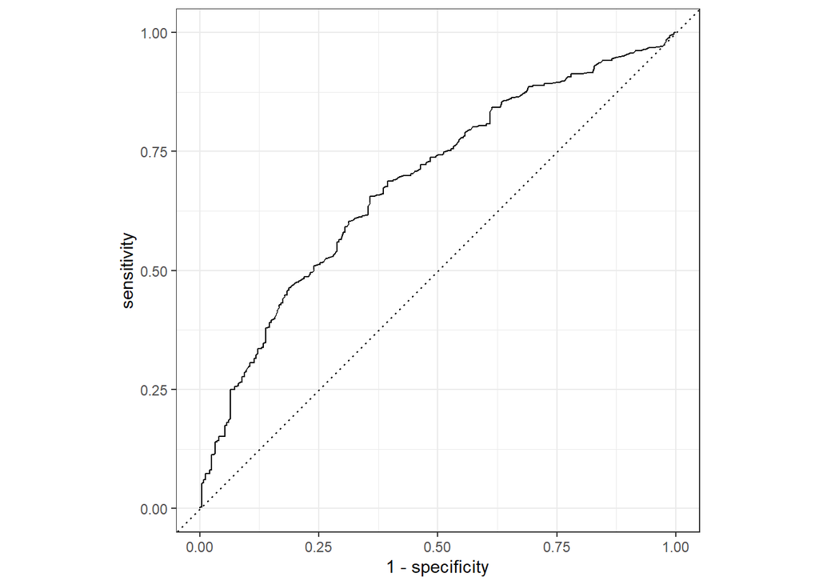

```r
lr_auc <- lr_res %>%
  collect_predictions(parameters = lr_best) %>%
  roc_curve(Mean_group, .pred_Abnormal) %>% # predicts if they have abnormal levels
  mutate(model = "Logistic Regression")

autoplot(lr_auc)
```

### Tree-Based Ensemble Model

Finding the number of cores available:

```r
cores <- parallel::detectCores()
cores
```

```
## [1] 4
```

Building the model:

```r
rf_mod <-
  rand_forest(mtry = tune(), min_n = tune(), trees = 1000) %>%
  set_engine("ranger", num.threads = cores) %>%
  set_mode("classification")
```

Creating the recipe:

```r
rf_recipe <-
  recipe(Mean_group ~ ., data = AG_other)
```

Creating the workflow:

```r
rf_workflow <- workflow() %>%
  add_model(rf_mod) %>%
  add_recipe(rf_recipe)
```

Hyperparameters:

```r
rf_mod
```

```
## Random Forest Model Specification (classification)
##
## Main Arguments:
##   mtry = tune()
##   trees = 1000
##   min_n = tune()
##
## Engine-Specific Arguments:
##   num.threads = cores
##
## Computational engine: ranger
```

```r
extract_parameter_set_dials(rf_mod)
```

```
## Collection of 2 parameters for tuning
##
##  identifier  type    object
##        mtry  mtry nparam[?]
##       min_n min_n nparam[+]
##
## Model parameters needing finalization:
##    # Randomly Selected Predictors ('mtry')
##
## See `?dials::finalize` or `?dials::update.parameters` for more information.
```

Generating grid of candidate models:

```r
set.seed(345)
rf_res <- rf_workflow %>%
  tune_grid(val_set, grid = 25, control = control_grid(save_pred = TRUE),
            metrics = metric_set(roc_auc))
```

```
## i Creating pre-processing data to finalize unknown parameter: mtry
```

Showing the top 5 random forest models:

```r
rf_res %>%
  show_best(metric = "roc_auc")
```

```
## # A tibble: 5 × 8
##    mtry min_n .metric .estimator  mean     n std_err .config
##   <int> <int> <chr>   <chr>      <dbl> <int>   <dbl> <chr>
## 1     1    38 roc_auc binary     0.682     1      NA Preprocessor1_Model07
## 2     2    35 roc_auc binary     0.675     1      NA Preprocessor1_Model12
## 3     2    31 roc_auc binary     0.675     1      NA Preprocessor1_Model15
## 4     2     3 roc_auc binary     0.671     1      NA Preprocessor1_Model21
## 5     3    25 roc_auc binary     0.665     1      NA Preprocessor1_Model03
```

Plotting the models:

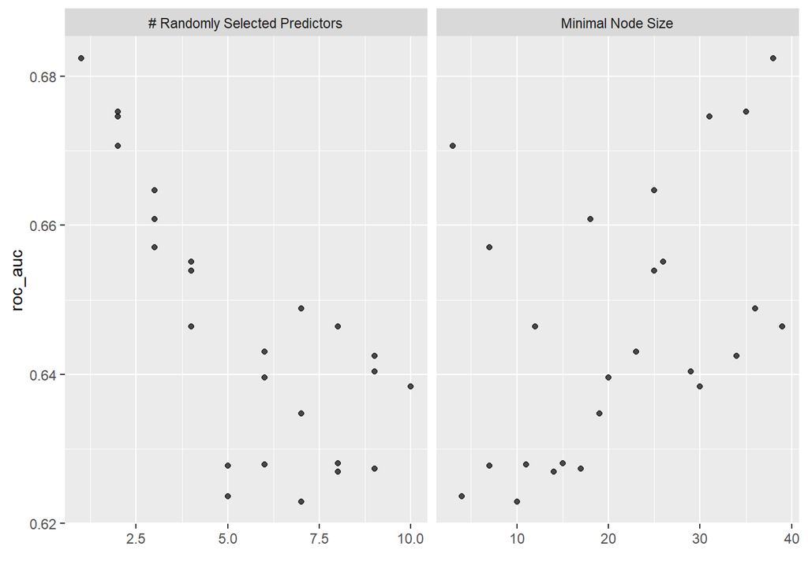

```r
autoplot(rf_res)
```

Selecting the best model according to ROC AUC:

```r
rf_best <- rf_res %>%
  select_best(metric = "roc_auc")
rf_best
```

```
## # A tibble: 1 × 3
##    mtry min_n .config
##   <int> <int> <chr>
## 1     1    38 Preprocessor1_Model07
```

Calculating the data needed to plot the ROC curve:

```r
rf_auc <- rf_res %>%
  collect_predictions(parameters = rf_best) %>%
  roc_curve(Mean_group, .pred_Abnormal) %>%
  mutate(model = "Random Forest")
```

Plotting and comparing the RF and PLR model:

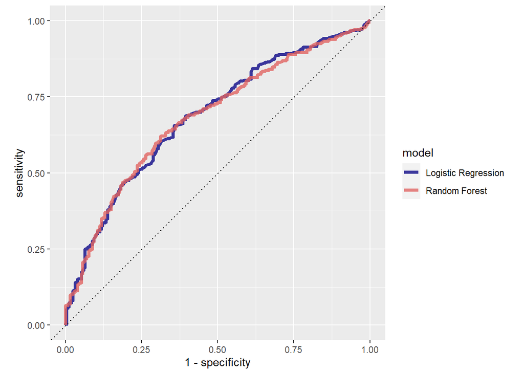

```r
bind_rows(rf_auc, lr_auc) %>%
  ggplot(aes(x = 1 - specificity, y = sensitivity, col = model)) +
  geom_path(lwd = 1.5, alpha = 0.8) +
  geom_abline(lty = 3) +
  coord_equal() +
  scale_color_viridis_d(option = "plasma", end = .6)
```

```r
last_lr_mod <-
  logistic_reg(penalty = 0.03039195, mixture = 1) %>%
  set_engine("glmnet", importance = "impurity")

last_lr_workflow <- lr_workflow %>%
  update_model(last_lr_mod)

last_lr_fit <- last_lr_workflow %>%
  last_fit(splits)

last_lr_fit %>%
  collect_metrics()
```

```
## # A tibble: 2 × 4
##   .metric  .estimator .estimate .config
##   <chr>    <chr>          <dbl> <chr>
## 1 accuracy binary         0.691 Preprocessor1_Model1
## 2 roc_auc  binary         0.736 Preprocessor1_Model1
```

The accuracy comes in at 69.1%, and the ROC AUC comes in at 73.6%. Not bad!

Visualizing the variable importance scores:

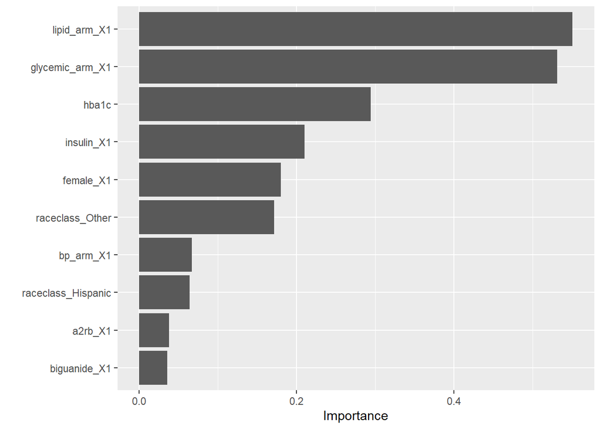

```r
last_lr_fit %>%
extract_fit_parsnip() %>%
  vip(num_features = 10)
```

The most important predictor in the model was the lipid arm treatment, followed closely by the glycemic arm treatment, and then hba1c.

Plotting the last ROC curve:

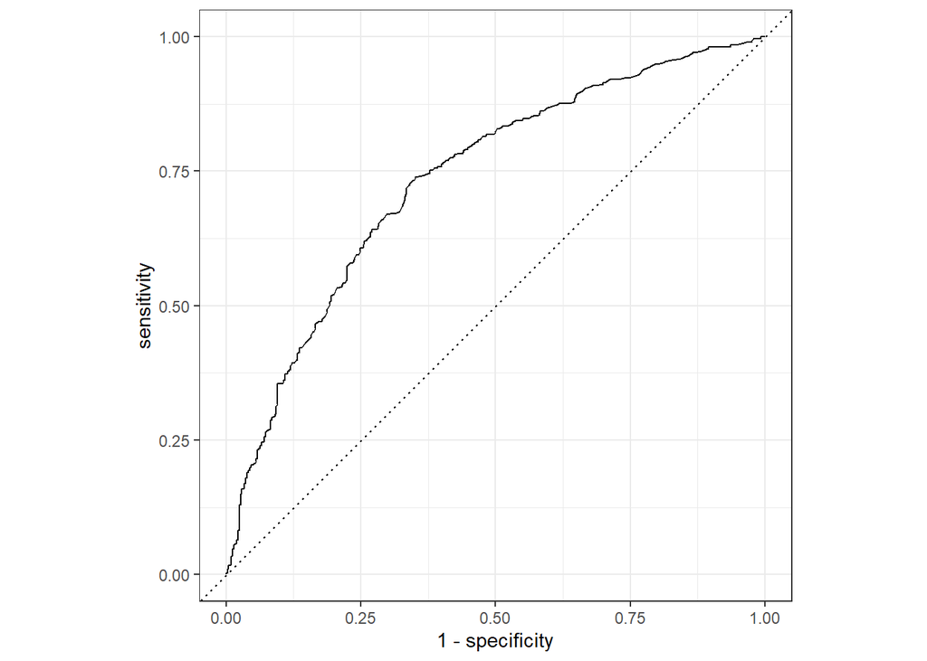

```r
last_lr_fit %>%
  collect_predictions() %>%
  roc_curve(Mean_group, .pred_Abnormal) %>%
  autoplot()
```